# Project: European Football Analysis

- Introduction
- Data Wrangling
- Exploratory Data Analysis
- Conclusions

## Introduction

> **Data:** The analysis is performed on the soccer database which comes from Kaggle. It contains data for soccer matches, players, and teams from several European countries from 2008 to 2016.

> **Questions:**
> - 1. Which teams improved the most over the time period?
> - 2. What team attributes lead to the most home team victories?
> - 3. Which player had the most penalties?

> **Code for retrieving teams data into a csv file from SQLite database:** ``` WITH t1 as (SELECT c.name country_name,l.name league_name, m.id match_id, m.season, m.stage, m.date, m.home_team_goal, m.away_team_goal, t.team_long_name home_team, t.team_short_name home_team_abbr, ta.chanceCreationPassing, ta.chanceCreationPassingClass, ta.chanceCreationShooting, ta.chanceCreationShootingClass, ta.defencePressure, ta.defencePressureClass

FROM Country as c JOIN League as l on c.id = l.country_id JOIN Match as m on l.id = m.league_id JOIN Team as t on m.home_team_api_id = t.team_api_id JOIN Team_Attributes as ta on t.team_api_id = ta.team_api_id order by m.date DESC),

t2 as (SELECT m.id match_id, t.team_long_name away_team, t.team_short_name away_team_abbr FROM Match as m JOIN Team as t on m.away_team_api_id = t.team_api_id)

SELECT t1.*, t2.away_team, t2.away_team_abbr FROM t1 JOIN t2 on t1.match_id = t2.match_id ```

> **Importing relevant packages for data analysis**

```python
import pandas as pd
import numpy as np
import matplotlib.pyplot as plt
import seaborn as sns
%matplotlib inline
sns.set_style('darkgrid')
plt.rcParams['figure.figsize']=10,6
```

## Data Wrangling

> **Tasks**: In this section of the report, three tasks will be performed. Firstly, *gathering* data (loading data) into the jupyter notebook. Secondly, *assessing* the quality of the data. Thirdly, *cleaning* the data for efficient analysis.

### Gathering Data and discussing its general properties

```python
# Loading data and print out a few lines

df = pd.read_csv('European_Football_Data.csv')
df.head()
```

|  | country_name | league_name | match_id | season | stage | date | home_team_goal | away_team_goal | home_team | home_team_abbr | chanceCreationPassing | chanceCreationPassingClass | chanceCreationShooting | chanceCreationShootingClass | defencePressure | defencePressureClass | away_team | away_team_abbr |
| --- | --- | --- | --- | --- | --- | --- | --- | --- | --- | --- | --- | --- | --- | --- | --- | --- | --- | --- |
| 0 | Switzerland | Switzerland Super League | 25945 | 2015/2016 | 36 | 2016-05-25 00:00:00 | 0 | 1 | FC Basel | BAS | 50 | Normal | 50 | Normal | 60 | Medium | Grasshopper Club Zürich | GRA |
| 1 | Switzerland | Switzerland Super League | 25945 | 2015/2016 | 36 | 2016-05-25 00:00:00 | 0 | 1 | FC Basel | BAS | 51 | Normal | 49 | Normal | 38 | Medium | Grasshopper Club Zürich | GRA |
| 2 | Switzerland | Switzerland Super League | 25945 | 2015/2016 | 36 | 2016-05-25 00:00:00 | 0 | 1 | FC Basel | BAS | 66 | Normal | 54 | Normal | 47 | Medium | Grasshopper Club Zürich | GRA |
| 3 | Switzerland | Switzerland Super League | 25945 | 2015/2016 | 36 | 2016-05-25 00:00:00 | 0 | 1 | FC Basel | BAS | 66 | Normal | 54 | Normal | 47 | Medium | Grasshopper Club Zürich | GRA |
| 4 | Switzerland | Switzerland Super League | 25945 | 2015/2016 | 36 | 2016-05-25 00:00:00 | 0 | 1 | FC Basel | BAS | 66 | Normal | 54 | Normal | 47 | Medium | Grasshopper Club Zürich | GRA |

```python
# Dimensions of the dataframe (rows, columns)

df.shape
```

```
(142093, 18)
```

```python
# Printing the column labels in the dataframe

for i, v in enumerate(df.columns):
    print(i, v)
```

```
0 country_name
1 league_name
2 match_id
3 season
4 stage
5 date
6 home_team_goal
7 away_team_goal
8 home_team
9 home_team_abbr
10 chanceCreationPassing
11 chanceCreationPassingClass
12 chanceCreationShooting
13 chanceCreationShootingClass
14 defencePressure
15 defencePressureClass
16 away_team
17 away_team_abbr
```

```python
# Checking datatypes of columns

df.dtypes
```

```
country_name                   object
league_name                    object
match_id                        int64
season                         object
stage                           int64
date                           object
home_team_goal                  int64
away_team_goal                  int64
home_team                      object
home_team_abbr                 object
chanceCreationPassing           int64
chanceCreationPassingClass     object
chanceCreationShooting          int64
chanceCreationShootingClass    object
defencePressure                 int64
defencePressureClass           object
away_team                      object
away_team_abbr                 object
dtype: object
```

> **date attribute is of string datatype**

```python
# No of unique values in each column

df.nunique()
```

```
country_name                      11
league_name                       11
match_id                       25801
season                             8
stage                             38
date                            1690
home_team_goal                    11
away_team_goal                    10
home_team                        285
home_team_abbr                   251
chanceCreationPassing             50
chanceCreationPassingClass         3
chanceCreationShooting            57
chanceCreationShootingClass        3
defencePressure                   48
defencePressureClass               3
away_team                        296
away_team_abbr                   259
dtype: int64
```

### Assessing Data

#### Checking for missing values

```python
df.isnull().sum()
```

```
country_name                   0
league_name                    0
match_id                       0
season                         0
stage                          0
date                           0
home_team_goal                 0
away_team_goal                 0
home_team                      0
home_team_abbr                 0
chanceCreationPassing          0
chanceCreationPassingClass     0
chanceCreationShooting         0
chanceCreationShootingClass    0
defencePressure                0
defencePressureClass           0
away_team                      0
away_team_abbr                 0
dtype: int64
```

> **No missing values found**

#### Checking for duplicates

```python
sum(df.duplicated())
```

```
22529
```

> **22,529 duplicate entries found**

### Cleaning Data

#### Removing duplicates

```python
df.drop_duplicates(inplace = True)
```

```python
sum(df.duplicated())
```

```
0
```

#### Renaming some column names to make all look consistent

```python
df.rename(columns={'chanceCreationPassing':'chance_Creation_Passing', \
                    'chanceCreationPassingClass': 'chance_Creation_Passing_Class', \
                   'chanceCreationShooting':'chance_Creation_Shooting', \
                   'chanceCreationShootingClass':'chance_Creation_Shooting_Class',\
                   'defencePressure':'defence_Pressure', 'defencePressureClass': 'defence_Pressure_Class'}, inplace=True)
```

```python
# Making all the column names lower case for more consistency
df.rename(columns=lambda x:x.lower(), inplace=True)
```

```python
# Final column names
for i, v in enumerate(df.columns):
    print(i, v)
```

```
0 country_name
1 league_name
2 match_id
3 season
4 stage
5 date
6 home_team_goal
7 away_team_goal
8 home_team
9 home_team_abbr
10 chance_creation_passing
11 chance_creation_passing_class
12 chance_creation_shooting
13 chance_creation_shooting_class
14 defence_pressure
15 defence_pressure_class
16 away_team
17 away_team_abbr
```

#### Fixing datatypes such as date being a string

```python
df.date = pd.to_datetime(df.date)
```

```python
type(df.date[0])
```

```
pandas._libs.tslibs.timestamps.Timestamp
```

#### Adding goal differences (GD) for both home and away team

```python
home_GD = df.home_team_goal - df.away_team_goal
df['home_GD'] = home_GD
```

```python
df.head()
```

|  | country_name | league_name | match_id | season | stage | date | home_team_goal | away_team_goal | home_team | home_team_abbr | chance_creation_passing | chance_creation_passing_class | chance_creation_shooting | chance_creation_shooting_class | defence_pressure | defence_pressure_class | away_team | away_team_abbr | home_GD |
| --- | --- | --- | --- | --- | --- | --- | --- | --- | --- | --- | --- | --- | --- | --- | --- | --- | --- | --- | --- |
| 0 | Switzerland | Switzerland Super League | 25945 | 2015/2016 | 36 | 2016-05-25 | 0 | 1 | FC Basel | BAS | 50 | Normal | 50 | Normal | 60 | Medium | Grasshopper Club Zürich | GRA | -1 |
| 1 | Switzerland | Switzerland Super League | 25945 | 2015/2016 | 36 | 2016-05-25 | 0 | 1 | FC Basel | BAS | 51 | Normal | 49 | Normal | 38 | Medium | Grasshopper Club Zürich | GRA | -1 |
| 2 | Switzerland | Switzerland Super League | 25945 | 2015/2016 | 36 | 2016-05-25 | 0 | 1 | FC Basel | BAS | 66 | Normal | 54 | Normal | 47 | Medium | Grasshopper Club Zürich | GRA | -1 |
| 6 | Switzerland | Switzerland Super League | 25947 | 2015/2016 | 36 | 2016-05-25 | 2 | 2 | FC Luzern | LUZ | 45 | Normal | 60 | Normal | 40 | Medium | FC Sion | SIO | 0 |
| 7 | Switzerland | Switzerland Super League | 25947 | 2015/2016 | 36 | 2016-05-25 | 2 | 2 | FC Luzern | LUZ | 51 | Normal | 55 | Normal | 48 | Medium | FC Sion | SIO | 0 |

```python
away_GD = df.away_team_goal - df.home_team_goal
df['away_GD'] = away_GD
```

```python
df.head()
```

|  | country_name | league_name | match_id | season | stage | date | home_team_goal | away_team_goal | home_team | home_team_abbr | chance_creation_passing | chance_creation_passing_class | chance_creation_shooting | chance_creation_shooting_class | defence_pressure | defence_pressure_class | away_team | away_team_abbr | home_GD | away_GD |
| --- | --- | --- | --- | --- | --- | --- | --- | --- | --- | --- | --- | --- | --- | --- | --- | --- | --- | --- | --- | --- |
| 0 | Switzerland | Switzerland Super League | 25945 | 2015/2016 | 36 | 2016-05-25 | 0 | 1 | FC Basel | BAS | 50 | Normal | 50 | Normal | 60 | Medium | Grasshopper Club Zürich | GRA | -1 | 1 |
| 1 | Switzerland | Switzerland Super League | 25945 | 2015/2016 | 36 | 2016-05-25 | 0 | 1 | FC Basel | BAS | 51 | Normal | 49 | Normal | 38 | Medium | Grasshopper Club Zürich | GRA | -1 | 1 |
| 2 | Switzerland | Switzerland Super League | 25945 | 2015/2016 | 36 | 2016-05-25 | 0 | 1 | FC Basel | BAS | 66 | Normal | 54 | Normal | 47 | Medium | Grasshopper Club Zürich | GRA | -1 | 1 |
| 6 | Switzerland | Switzerland Super League | 25947 | 2015/2016 | 36 | 2016-05-25 | 2 | 2 | FC Luzern | LUZ | 45 | Normal | 60 | Normal | 40 | Medium | FC Sion | SIO | 0 | 0 |
| 7 | Switzerland | Switzerland Super League | 25947 | 2015/2016 | 36 | 2016-05-25 | 2 | 2 | FC Luzern | LUZ | 51 | Normal | 55 | Normal | 48 | Medium | FC Sion | SIO | 0 | 0 |

#### Adding home team match status

```python
def check_value3(cell_value = 0):
    if cell_value > 0:
        return 'w'
    elif cell_value == 0:
        return 'd'
    else:
        return 'l'

df['home_stat'] = df['home_GD'].apply(check_value3)
df.head()
```

|  | country_name | league_name | match_id | season | stage | date | home_team_goal | away_team_goal | home_team | home_team_abbr | ... | chance_creation_passing_class | chance_creation_shooting | chance_creation_shooting_class | defence_pressure | defence_pressure_class | away_team | away_team_abbr | home_GD | away_GD | home_stat |
| --- | --- | --- | --- | --- | --- | --- | --- | --- | --- | --- | --- | --- | --- | --- | --- | --- | --- | --- | --- | --- | --- |
| 0 | Switzerland | Switzerland Super League | 25945 | 2015/2016 | 36 | 2016-05-25 | 0 | 1 | FC Basel | BAS | ... | Normal | 50 | Normal | 60 | Medium | Grasshopper Club Zürich | GRA | -1 | 1 | l |
| 1 | Switzerland | Switzerland Super League | 25945 | 2015/2016 | 36 | 2016-05-25 | 0 | 1 | FC Basel | BAS | ... | Normal | 49 | Normal | 38 | Medium | Grasshopper Club Zürich | GRA | -1 | 1 | l |
| 2 | Switzerland | Switzerland Super League | 25945 | 2015/2016 | 36 | 2016-05-25 | 0 | 1 | FC Basel | BAS | ... | Normal | 54 | Normal | 47 | Medium | Grasshopper Club Zürich | GRA | -1 | 1 | l |
| 6 | Switzerland | Switzerland Super League | 25947 | 2015/2016 | 36 | 2016-05-25 | 2 | 2 | FC Luzern | LUZ | ... | Normal | 60 | Normal | 40 | Medium | FC Sion | SIO | 0 | 0 | d |
| 7 | Switzerland | Switzerland Super League | 25947 | 2015/2016 | 36 | 2016-05-25 | 2 | 2 | FC Luzern | LUZ | ... | Normal | 55 | Normal | 48 | Medium | FC Sion | SIO | 0 | 0 | d |

5 rows × 21 columns

#### Adding away team match status

```python
df['away_stat'] = df['away_GD'].apply(check_value3)
df.head()
```

|  | country_name | league_name | match_id | season | stage | date | home_team_goal | away_team_goal | home_team | home_team_abbr | ... | chance_creation_shooting | chance_creation_shooting_class | defence_pressure | defence_pressure_class | away_team | away_team_abbr | home_GD | away_GD | home_stat | away_stat |
| --- | --- | --- | --- | --- | --- | --- | --- | --- | --- | --- | --- | --- | --- | --- | --- | --- | --- | --- | --- | --- | --- |
| 0 | Switzerland | Switzerland Super League | 25945 | 2015/2016 | 36 | 2016-05-25 | 0 | 1 | FC Basel | BAS | ... | 50 | Normal | 60 | Medium | Grasshopper Club Zürich | GRA | -1 | 1 | l | w |
| 1 | Switzerland | Switzerland Super League | 25945 | 2015/2016 | 36 | 2016-05-25 | 0 | 1 | FC Basel | BAS | ... | 49 | Normal | 38 | Medium | Grasshopper Club Zürich | GRA | -1 | 1 | l | w |
| 2 | Switzerland | Switzerland Super League | 25945 | 2015/2016 | 36 | 2016-05-25 | 0 | 1 | FC Basel | BAS | ... | 54 | Normal | 47 | Medium | Grasshopper Club Zürich | GRA | -1 | 1 | l | w |
| 6 | Switzerland | Switzerland Super League | 25947 | 2015/2016 | 36 | 2016-05-25 | 2 | 2 | FC Luzern | LUZ | ... | 60 | Normal | 40 | Medium | FC Sion | SIO | 0 | 0 | d | d |
| 7 | Switzerland | Switzerland Super League | 25947 | 2015/2016 | 36 | 2016-05-25 | 2 | 2 | FC Luzern | LUZ | ... | 55 | Normal | 48 | Medium | FC Sion | SIO | 0 | 0 | d | d |

5 rows × 22 columns

#### Adding points to home team based on match status {win = 3, draw = 1 , lose = 0}

```python
def check_value2(cell_value = 'w'):
    if cell_value =='w':
        return 3
    elif cell_value =='d':
        return 1
    else:
        return 0

df['home_points'] = df['home_stat'].apply(check_value2)
df.head()
```

|  | country_name | league_name | match_id | season | stage | date | home_team_goal | away_team_goal | home_team | home_team_abbr | ... | chance_creation_shooting_class | defence_pressure | defence_pressure_class | away_team | away_team_abbr | home_GD | away_GD | home_stat | away_stat | home_points |
| --- | --- | --- | --- | --- | --- | --- | --- | --- | --- | --- | --- | --- | --- | --- | --- | --- | --- | --- | --- | --- | --- |
| 0 | Switzerland | Switzerland Super League | 25945 | 2015/2016 | 36 | 2016-05-25 | 0 | 1 | FC Basel | BAS | ... | Normal | 60 | Medium | Grasshopper Club Zürich | GRA | -1 | 1 | l | w | 0 |
| 1 | Switzerland | Switzerland Super League | 25945 | 2015/2016 | 36 | 2016-05-25 | 0 | 1 | FC Basel | BAS | ... | Normal | 38 | Medium | Grasshopper Club Zürich | GRA | -1 | 1 | l | w | 0 |
| 2 | Switzerland | Switzerland Super League | 25945 | 2015/2016 | 36 | 2016-05-25 | 0 | 1 | FC Basel | BAS | ... | Normal | 47 | Medium | Grasshopper Club Zürich | GRA | -1 | 1 | l | w | 0 |
| 6 | Switzerland | Switzerland Super League | 25947 | 2015/2016 | 36 | 2016-05-25 | 2 | 2 | FC Luzern | LUZ | ... | Normal | 40 | Medium | FC Sion | SIO | 0 | 0 | d | d | 1 |
| 7 | Switzerland | Switzerland Super League | 25947 | 2015/2016 | 36 | 2016-05-25 | 2 | 2 | FC Luzern | LUZ | ... | Normal | 48 | Medium | FC Sion | SIO | 0 | 0 | d | d | 1 |

5 rows × 23 columns

#### Adding points to away team based on match status {win = 3, draw = 1 , lose = 0}

```python
df['away_points'] = df['away_stat'].apply(check_value2)
df.head()
```

|  | country_name | league_name | match_id | season | stage | date | home_team_goal | away_team_goal | home_team | home_team_abbr | ... | defence_pressure | defence_pressure_class | away_team | away_team_abbr | home_GD | away_GD | home_stat | away_stat | home_points | away_points |
| --- | --- | --- | --- | --- | --- | --- | --- | --- | --- | --- | --- | --- | --- | --- | --- | --- | --- | --- | --- | --- | --- |
| 0 | Switzerland | Switzerland Super League | 25945 | 2015/2016 | 36 | 2016-05-25 | 0 | 1 | FC Basel | BAS | ... | 60 | Medium | Grasshopper Club Zürich | GRA | -1 | 1 | l | w | 0 | 3 |
| 1 | Switzerland | Switzerland Super League | 25945 | 2015/2016 | 36 | 2016-05-25 | 0 | 1 | FC Basel | BAS | ... | 38 | Medium | Grasshopper Club Zürich | GRA | -1 | 1 | l | w | 0 | 3 |
| 2 | Switzerland | Switzerland Super League | 25945 | 2015/2016 | 36 | 2016-05-25 | 0 | 1 | FC Basel | BAS | ... | 47 | Medium | Grasshopper Club Zürich | GRA | -1 | 1 | l | w | 0 | 3 |
| 6 | Switzerland | Switzerland Super League | 25947 | 2015/2016 | 36 | 2016-05-25 | 2 | 2 | FC Luzern | LUZ | ... | 40 | Medium | FC Sion | SIO | 0 | 0 | d | d | 1 | 1 |
| 7 | Switzerland | Switzerland Super League | 25947 | 2015/2016 | 36 | 2016-05-25 | 2 | 2 | FC Luzern | LUZ | ... | 48 | Medium | FC Sion | SIO | 0 | 0 | d | d | 1 | 1 |

5 rows × 24 columns

#### Adding wins to home team based on match status {w = 1, draw = 0 , lose = 0}

```python
def check_value(cell_value = 'w'):
    if cell_value == 'w':
        return 1
    else:
        return 0


df['home_win'] = df['home_stat'].apply(check_value)
df.head()
```

|  | country_name | league_name | match_id | season | stage | date | home_team_goal | away_team_goal | home_team | home_team_abbr | ... | defence_pressure_class | away_team | away_team_abbr | home_GD | away_GD | home_stat | away_stat | home_points | away_points | home_win |
| --- | --- | --- | --- | --- | --- | --- | --- | --- | --- | --- | --- | --- | --- | --- | --- | --- | --- | --- | --- | --- | --- |
| 0 | Switzerland | Switzerland Super League | 25945 | 2015/2016 | 36 | 2016-05-25 | 0 | 1 | FC Basel | BAS | ... | Medium | Grasshopper Club Zürich | GRA | -1 | 1 | l | w | 0 | 3 | 0 |
| 1 | Switzerland | Switzerland Super League | 25945 | 2015/2016 | 36 | 2016-05-25 | 0 | 1 | FC Basel | BAS | ... | Medium | Grasshopper Club Zürich | GRA | -1 | 1 | l | w | 0 | 3 | 0 |
| 2 | Switzerland | Switzerland Super League | 25945 | 2015/2016 | 36 | 2016-05-25 | 0 | 1 | FC Basel | BAS | ... | Medium | Grasshopper Club Zürich | GRA | -1 | 1 | l | w | 0 | 3 | 0 |
| 6 | Switzerland | Switzerland Super League | 25947 | 2015/2016 | 36 | 2016-05-25 | 2 | 2 | FC Luzern | LUZ | ... | Medium | FC Sion | SIO | 0 | 0 | d | d | 1 | 1 | 0 |
| 7 | Switzerland | Switzerland Super League | 25947 | 2015/2016 | 36 | 2016-05-25 | 2 | 2 | FC Luzern | LUZ | ... | Medium | FC Sion | SIO | 0 | 0 | d | d | 1 | 1 | 0 |

5 rows × 25 columns

#### Adding wins to away team based on match status {w = 1, draw = 0 , lose = 0}

```python
df['away_win'] = df['away_stat'].apply(check_value)
df.head()
```

|  | country_name | league_name | match_id | season | stage | date | home_team_goal | away_team_goal | home_team | home_team_abbr | ... | away_team | away_team_abbr | home_GD | away_GD | home_stat | away_stat | home_points | away_points | home_win | away_win |
| --- | --- | --- | --- | --- | --- | --- | --- | --- | --- | --- | --- | --- | --- | --- | --- | --- | --- | --- | --- | --- | --- |
| 0 | Switzerland | Switzerland Super League | 25945 | 2015/2016 | 36 | 2016-05-25 | 0 | 1 | FC Basel | BAS | ... | Grasshopper Club Zürich | GRA | -1 | 1 | l | w | 0 | 3 | 0 | 1 |
| 1 | Switzerland | Switzerland Super League | 25945 | 2015/2016 | 36 | 2016-05-25 | 0 | 1 | FC Basel | BAS | ... | Grasshopper Club Zürich | GRA | -1 | 1 | l | w | 0 | 3 | 0 | 1 |
| 2 | Switzerland | Switzerland Super League | 25945 | 2015/2016 | 36 | 2016-05-25 | 0 | 1 | FC Basel | BAS | ... | Grasshopper Club Zürich | GRA | -1 | 1 | l | w | 0 | 3 | 0 | 1 |
| 6 | Switzerland | Switzerland Super League | 25947 | 2015/2016 | 36 | 2016-05-25 | 2 | 2 | FC Luzern | LUZ | ... | FC Sion | SIO | 0 | 0 | d | d | 1 | 1 | 0 | 0 |
| 7 | Switzerland | Switzerland Super League | 25947 | 2015/2016 | 36 | 2016-05-25 | 2 | 2 | FC Luzern | LUZ | ... | FC Sion | SIO | 0 | 0 | d | d | 1 | 1 | 0 | 0 |

5 rows × 26 columns

#### Dimensions of the dataframe after cleaning

```python
# Eight new columns added
df.shape
```

```
(119564, 26)
```

```python
df.head()
```

|  | country_name | league_name | match_id | season | stage | date | home_team_goal | away_team_goal | home_team | home_team_abbr | ... | away_team | away_team_abbr | home_GD | away_GD | home_stat | away_stat | home_points | away_points | home_win | away_win |
| --- | --- | --- | --- | --- | --- | --- | --- | --- | --- | --- | --- | --- | --- | --- | --- | --- | --- | --- | --- | --- | --- |
| 0 | Switzerland | Switzerland Super League | 25945 | 2015/2016 | 36 | 2016-05-25 | 0 | 1 | FC Basel | BAS | ... | Grasshopper Club Zürich | GRA | -1 | 1 | l | w | 0 | 3 | 0 | 1 |
| 1 | Switzerland | Switzerland Super League | 25945 | 2015/2016 | 36 | 2016-05-25 | 0 | 1 | FC Basel | BAS | ... | Grasshopper Club Zürich | GRA | -1 | 1 | l | w | 0 | 3 | 0 | 1 |
| 2 | Switzerland | Switzerland Super League | 25945 | 2015/2016 | 36 | 2016-05-25 | 0 | 1 | FC Basel | BAS | ... | Grasshopper Club Zürich | GRA | -1 | 1 | l | w | 0 | 3 | 0 | 1 |
| 6 | Switzerland | Switzerland Super League | 25947 | 2015/2016 | 36 | 2016-05-25 | 2 | 2 | FC Luzern | LUZ | ... | FC Sion | SIO | 0 | 0 | d | d | 1 | 1 | 0 | 0 |
| 7 | Switzerland | Switzerland Super League | 25947 | 2015/2016 | 36 | 2016-05-25 | 2 | 2 | FC Luzern | LUZ | ... | FC Sion | SIO | 0 | 0 | d | d | 1 | 1 | 0 | 0 |

5 rows × 26 columns

## Exploratory Data Analysis

### Question 1: Which teams improved the most over the time period?

#### Analyzing home and away statistics of teams

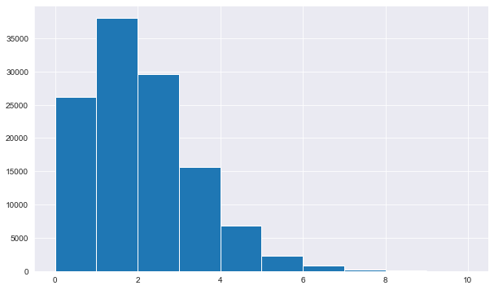

```python
# Plotting the distribution of home team goals
plt.hist(df.home_team_goal);
```

> **The distribution is positively skewed depicting majority of the home teams scoring utmost 3 goals.**

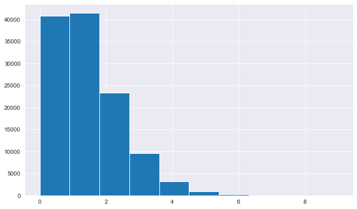

```python
# Plotting the distribution of away team goals
plt.hist(df.away_team_goal);
```

> **The distribution is also positively skewed depicting majority of the away teams scoring utmost 1 goal.**

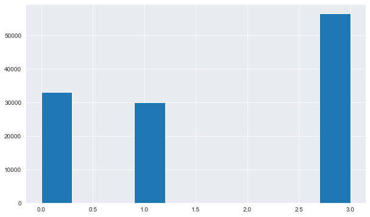

```python
# Plotting the distribution of home points
df['home_points'].hist();
```

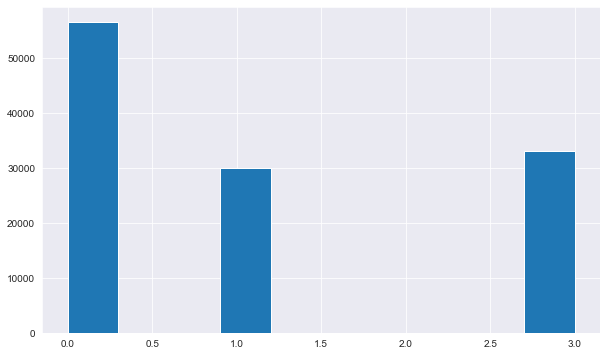

```python
# Plotting the distribution of away points
df['away_points'].hist();
```

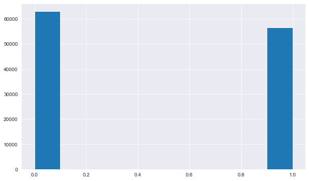

```python
# Plotting the distribution of home win
df['home_win'].hist();
```

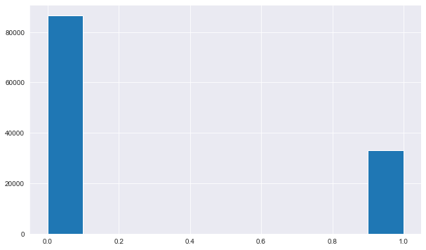

```python
# Plotting the distribution of away win
df['away_win'].hist();
```

> **As expected from the home points and away points distribution, the above home and away win plots depicting insignificant difference between the win and lose/draw for home matches which becomes significant when it comes to away matches. Hence, it is evident that winning away matches is difficult as compared to home matches and teams with high away win records are expected to be higher in the overall ranking of top teams over the period.**

#### Top five home teams over the time period

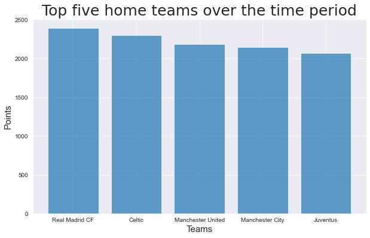

```python
# Grouping by home team and aggregation of home points
home_team_points = df.groupby('home_team')['home_points'].sum()


# Top five home teams
home_team_points_top5 = home_team_points.nlargest(n=5)

# Plotting the graph
plt.bar(home_team_points_top5.index, home_team_points_top5, alpha=0.7)
plt.title('Top five home teams over the time period', fontsize=25,fontname='Console')
plt.ylabel('Points',fontsize=15)
plt.xlabel('Teams', fontsize=15)
plt.xticks(fontsize=10)
plt.show()
```

#### Top five away teams over the time period

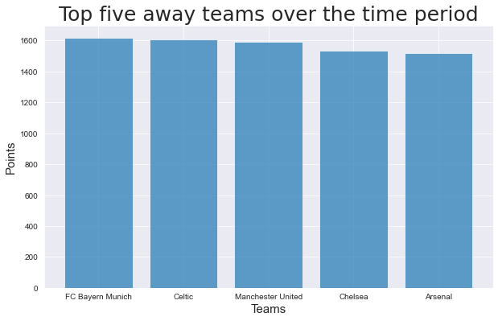

```python
# Grouping by away team and aggregation of away points
away_team_points = df.groupby('away_team')['away_points'].sum()

# Top five away teams
away_team_points_top5 = away_team_points.nlargest(n=5)

# Plotting the graph
plt.bar(away_team_points_top5.index, away_team_points_top5, alpha=0.7)
plt.title('Top five away teams over the time period', fontsize=25,fontname='Console')
plt.ylabel('Points',fontsize=15)
plt.xlabel('Teams', fontsize=15)
plt.xticks(fontsize=10)
plt.show()
```

#### Top five teams over the time period

```python
# Checking for missing values in home team points
home_team_points.isnull().sum()
```

```
0
```

```python
# Checking for missing values in away team points
away_team_points.isnull().sum()
```

```
0
```

```python
# Combining home and away points for each team
total_team_points = home_team_points + away_team_points
total_team_points
```

```
1. FC Kaiserslautern         409.0
1. FC Köln                  1251.0
1. FC Nürnberg              1132.0
1. FSV Mainz 05             1952.0
AC Ajaccio                   353.0
                             ...
Xerez Club Deportivo         118.0
Zagłębie Lubin              1024.0
Zawisza Bydgoszcz            206.0
Évian Thonon Gaillard FC     686.0
Śląsk Wrocław               1770.0
Length: 296, dtype: float64
```

```python
# Checking for missing values in total team points
total_team_points.isnull().sum()
```

```
11
```

```python
# Dropping missing values in total team points
total_team_points.dropna(inplace=True)
```

```python
# Verifying that the missing values have been dropped
total_team_points.isnull().sum()
```

```
0
```

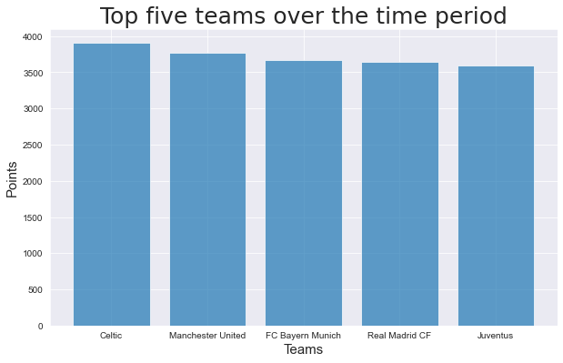

```python
# Top five teams over the time period

total_team_points_top5 = total_team_points.nlargest(n=5)

plt.bar(total_team_points_top5.index, total_team_points_top5, alpha=0.7)
plt.title('Top five teams over the time period', fontsize=25, fontname='Console')
plt.ylabel('Points',fontsize=15)
plt.xlabel('Teams', fontsize=15)
plt.xticks(fontsize=10)
plt.show()
```

> **As expected, top away teams, namely Celtic, Manchester United and FC Bayern Munich are higher as compared to the top home team Real Madrid CF in the overall ranking of top teams over the period.**

### Question 2: What team attributes lead to the most home team victories?

```python
df_attr = df.copy()
```

```python
# Printing column names along with their indices
for i, v in enumerate(df_attr):
    print(i, v)
```

```
0 country_name
1 league_name
2 match_id
3 season
4 stage
5 date
6 home_team_goal
7 away_team_goal
8 home_team
9 home_team_abbr
10 chance_creation_passing
11 chance_creation_passing_class
12 chance_creation_shooting
13 chance_creation_shooting_class
14 defence_pressure
15 defence_pressure_class
16 away_team
17 away_team_abbr
18 home_GD
19 away_GD
20 home_stat
21 away_stat
22 home_points
23 away_points
24 home_win
25 away_win
```

#### Dropping non- numeric columns: 0,1,2,3,4,5,8,9,11,13,15,16,17,20,21

> **Non-numeric columns are not compatible with scatterplots which we will use to understand the factors affecting home team wins**

```python
df_attr.drop(df_attr.columns[np.r_[0:6,8:10,11,13,15:18,20:22]], axis=1, inplace=True)
```

```python
# Printing column names
for i, v in enumerate(df_attr):
    print(i, v)
```

```
0 home_team_goal
1 away_team_goal
2 chance_creation_passing
3 chance_creation_shooting
4 defence_pressure
5 home_GD
6 away_GD
7 home_points
8 away_points
9 home_win
10 away_win
```

#### Dropping some more columns (3,5,6,10) in order to focus on key attributes

```python
df_attr.drop(df_attr.columns[np.r_[3,5:7,10]], axis=1, inplace=True)
```

```python
# Printing final column names
for i, v in enumerate(df_attr):
    print(i, v)
```

```
0 home_team_goal
1 away_team_goal
2 chance_creation_passing
3 defence_pressure
4 home_points
5 away_points
6 home_win
```

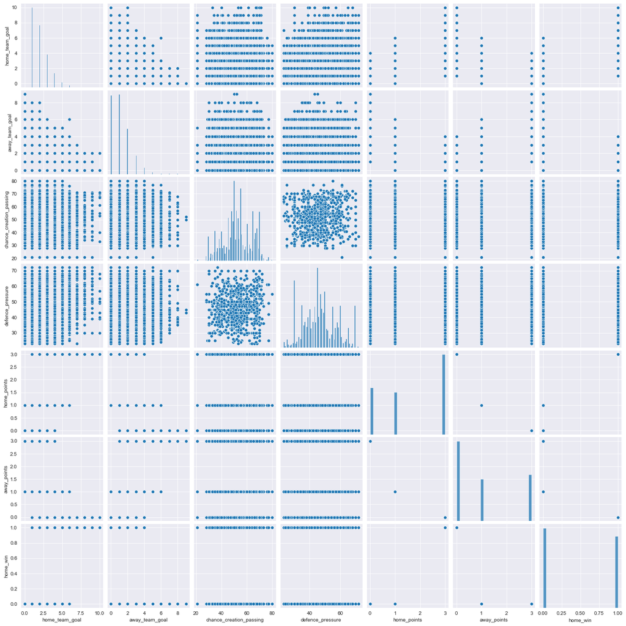

```python
sns.pairplot(df_attr);
```

> **Based on the above figure, it has come to light that home team goal, home points have positive relationship with home wins whereas away team goal and away points have negative relationship with home wins.**

### Question 3: Which player had the most penalties?

> **Code for retrieving player data into a csv file from SQLite database:** ``` SELECT p.*,pa.* from Player as p JOIN Player_Attributes as pa on p.player_api_id = pa.player_api_id

[output not shown]

|  | id | player_api_id | player_name | player_fifa_api_id | birthday | height | weight | id.1 | player_fifa_api_id.1 | player_api_id.1 | ... | vision | penalties | marking | standing_tackle | sliding_tackle | gk_diving | gk_handling | gk_kicking | gk_positioning | gk_reflexes |
| --- | --- | --- | --- | --- | --- | --- | --- | --- | --- | --- | --- | --- | --- | --- | --- | --- | --- | --- | --- | --- | --- |
| 0 | 1 | 505942 | Aaron Appindangoye | 218353 | 1992-02-29 00:00:00 | 182.88 | 187 | 1 | 218353 | 505942 | ... | 54.0 | 48.0 | 65.0 | 69.0 | 69.0 | 6.0 | 11.0 | 10.0 | 8.0 | 8.0 |
| 1 | 1 | 505942 | Aaron Appindangoye | 218353 | 1992-02-29 00:00:00 | 182.88 | 187 | 2 | 218353 | 505942 | ... | 54.0 | 48.0 | 65.0 | 69.0 | 69.0 | 6.0 | 11.0 | 10.0 | 8.0 | 8.0 |
| 2 | 1 | 505942 | Aaron Appindangoye | 218353 | 1992-02-29 00:00:00 | 182.88 | 187 | 3 | 218353 | 505942 | ... | 54.0 | 48.0 | 65.0 | 66.0 | 69.0 | 6.0 | 11.0 | 10.0 | 8.0 | 8.0 |
| 3 | 1 | 505942 | Aaron Appindangoye | 218353 | 1992-02-29 00:00:00 | 182.88 | 187 | 4 | 218353 | 505942 | ... | 53.0 | 47.0 | 62.0 | 63.0 | 66.0 | 5.0 | 10.0 | 9.0 | 7.0 | 7.0 |
| 4 | 1 | 505942 | Aaron Appindangoye | 218353 | 1992-02-29 00:00:00 | 182.88 | 187 | 5 | 218353 | 505942 | ... | 53.0 | 47.0 | 62.0 | 63.0 | 66.0 | 5.0 | 10.0 | 9.0 | 7.0 | 7.0 |

5 rows × 49 columns

```python
# Removing duplicated fifa_api_id, api_id, id columns
df2.drop(['id.1','player_api_id.1','player_fifa_api_id.1'], axis=1, inplace=True)
```

```python
df2.head()
```

|  | id | player_api_id | player_name | player_fifa_api_id | birthday | height | weight | date | overall_rating | potential | ... | vision | penalties | marking | standing_tackle | sliding_tackle | gk_diving | gk_handling | gk_kicking | gk_positioning | gk_reflexes |
| --- | --- | --- | --- | --- | --- | --- | --- | --- | --- | --- | --- | --- | --- | --- | --- | --- | --- | --- | --- | --- | --- |
| 0 | 1 | 505942 | Aaron Appindangoye | 218353 | 1992-02-29 00:00:00 | 182.88 | 187 | 2016-02-18 00:00:00 | 67.0 | 71.0 | ... | 54.0 | 48.0 | 65.0 | 69.0 | 69.0 | 6.0 | 11.0 | 10.0 | 8.0 | 8.0 |
| 1 | 1 | 505942 | Aaron Appindangoye | 218353 | 1992-02-29 00:00:00 | 182.88 | 187 | 2015-11-19 00:00:00 | 67.0 | 71.0 | ... | 54.0 | 48.0 | 65.0 | 69.0 | 69.0 | 6.0 | 11.0 | 10.0 | 8.0 | 8.0 |
| 2 | 1 | 505942 | Aaron Appindangoye | 218353 | 1992-02-29 00:00:00 | 182.88 | 187 | 2015-09-21 00:00:00 | 62.0 | 66.0 | ... | 54.0 | 48.0 | 65.0 | 66.0 | 69.0 | 6.0 | 11.0 | 10.0 | 8.0 | 8.0 |
| 3 | 1 | 505942 | Aaron Appindangoye | 218353 | 1992-02-29 00:00:00 | 182.88 | 187 | 2015-03-20 00:00:00 | 61.0 | 65.0 | ... | 53.0 | 47.0 | 62.0 | 63.0 | 66.0 | 5.0 | 10.0 | 9.0 | 7.0 | 7.0 |
| 4 | 1 | 505942 | Aaron Appindangoye | 218353 | 1992-02-29 00:00:00 | 182.88 | 187 | 2007-02-22 00:00:00 | 61.0 | 65.0 | ... | 53.0 | 47.0 | 62.0 | 63.0 | 66.0 | 5.0 | 10.0 | 9.0 | 7.0 | 7.0 |

5 rows × 46 columns

```python
# Dimensions of the dataframe
df2.shape
```

```
(183978, 46)
```

#### Assess process

```python
# Checking datatypes
df2.dtypes
```

```
id                       int64
player_api_id            int64
player_name             object
player_fifa_api_id       int64
birthday                object
height                 float64
weight                   int64
date                    object
overall_rating         float64
potential              float64
preferred_foot          object
attacking_work_rate     object
defensive_work_rate     object
crossing               float64
finishing              float64
heading_accuracy       float64
short_passing          float64
volleys                float64
dribbling              float64
curve                  float64
free_kick_accuracy     float64
long_passing           float64
ball_control           float64
acceleration           float64
sprint_speed           float64
agility                float64
reactions              float64
balance                float64
shot_power             float64
jumping                float64
stamina                float64
strength               float64
long_shots             float64
aggression             float64
interceptions          float64
positioning            float64
vision                 float64
penalties              float64
marking                float64
standing_tackle        float64
sliding_tackle         float64
gk_diving              float64
gk_handling            float64
gk_kicking             float64
gk_positioning         float64
gk_reflexes            float64
dtype: object
```

```python
# Checking for missing values
df2.isnull().sum()
```

```
id                        0
player_api_id             0
player_name               0
player_fifa_api_id        0
birthday                  0
height                    0
weight                    0
date                      0
overall_rating          836
potential               836
preferred_foot          836
attacking_work_rate    3230
defensive_work_rate     836
crossing                836
finishing               836
heading_accuracy        836
short_passing           836
volleys                2713
dribbling               836
curve                  2713
free_kick_accuracy      836
long_passing            836
ball_control            836
acceleration            836
sprint_speed            836
agility                2713
reactions               836
balance                2713
shot_power              836
jumping                2713
stamina                 836
strength                836
long_shots              836
aggression              836
interceptions           836
positioning             836
vision                 2713
penalties               836
marking                 836
standing_tackle         836
sliding_tackle         2713
gk_diving               836
gk_handling             836
gk_kicking              836
gk_positioning          836
gk_reflexes             836
dtype: int64
```

```python
# Checking for duplicated values
sum(df2.duplicated())
```

```
1
```